# Task 9.3

Hannes Guth

2022-11-20

## Data preparation

Before the actual analysis can be carried out, data have to be prepared. Since it is the same dataset at in task 6.4. and the exploratory part has been done there, no further data exploration will be done, here.  
The first step is to load the necessary packages for this task.

```r
library(data.table) # package for handling data in a datatable
library(caret) # package includes function RMSE
library(Hmisc) # package includes function cut2
library(rpart) # package for regressions/classification trees
library(rpart.plot) # package to plot regression/classification trees
library(tidyverse) # package order data
library(gtools) # package for combinations
```

```r
# read the dataset

corolla <- fread("ToyotaCorolla.csv") # read the data as a datatable
```

To carry out the machine learning in the next tasks, the dataset must be split into training and validation sets. (60:40)

```r
# Splitting

trainingIndex = sample(seq_len(nrow(corolla)), size = 0.6*nrow(corolla)) # assigning 60% of the indices of the initial dataset to trainingIndex
training = corolla[trainingIndex,] # training gets the to trainingIndex corresponding values
validation = corolla[-trainingIndex,] # validation gets the 40% of the data that have not been assigned to training
```

## a)

### Initial regression tree

In this section, the initial regression tree with a lot of features will be built before the subtasks i), ii), iii) will be approached.

As a first step, the desired variables are being selected.

```r
# Variable selection
variables <- c("Price", "Age_08_04", "KM", "Fuel_Type", "HP", "Automatic", "Doors", "Quarterly_Tax", "Mfr_Guarantee", "Guarantee_Period", "Airco", "Automatic_airco", "CD_Player", "Powered_Windows", "Sport_Model", "Tow_Bar") # these variables shall be used for the regression tree
training = training[, ..variables] # reduce the training set to these variables
```

Then the tree will be built in this section, setting the maximum levels of the tree to 30, the minimum number of observations in the terminal node to 1 and the complexity value 0.001.

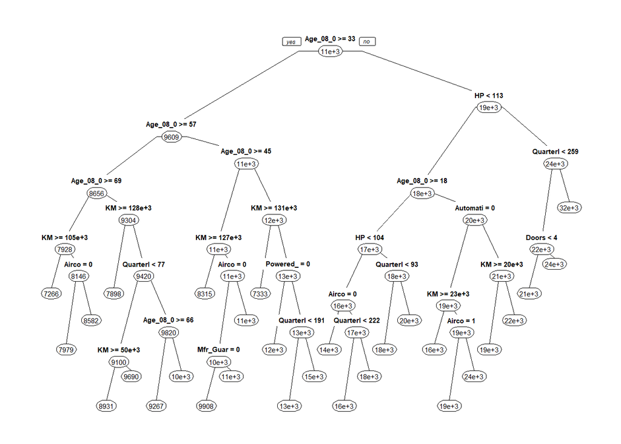

```r
# Regression Tree
set.seed(1) # reproducability
regrTreeTra <- rpart(Price ~ ., data = training, control = rpart.control(maxdepth = 30, minbucket = 1, cp = 0.001)) # regress price on every variable of training, set control variables: Max. number of levels of a tree cannot be bigger than 30 due to the function/system of the computer, minbucket describes the minimum number of observations in the last node and cp is the complexity, given by the task
prp(regrTreeTra, type = 1) # plot the tree
```

Concrete numbers about the tree are derived as follows.

```r
printcp(regrTreeTra)
```

```
##
## Regression tree:
## rpart(formula = Price ~ ., data = training, control = rpart.control(maxdepth = 30,
##     minbucket = 1, cp = 0.001))
##
## Variables actually used in tree construction:
## [1] Age_08_04       Airco           Automatic_airco Doors
## [5] HP              KM              Mfr_Guarantee   Powered_Windows
## [9] Quarterly_Tax
##
## Root node error: 1.1656e+10/861 = 13537642
##
## n= 861
##
##           CP nsplit rel error  xerror     xstd
```

[output cut: 28 more lines]

### i)

#### Which appear to be the three or four most important car specification for predicting the car’s price?

The first approach will directly use the information that are stored in the regression tree variable.

```r
importance <- data.frame(regrTreeTra$variable.importance) # take the variable importance directly from regression tree
importance <- rownames_to_column(importance, var = "Variables") # take names of the variable so that they can accessed later or are at least visible
importance <- data.table("Variables" = importance$Variables, "Importance" = importance$regrTreeTra.variable.importance)
importance
```

```
##            Variables Importance
##  1:        Age_08_04 9919436473
##  2:               KM 3302268738
##  3:  Automatic_airco 2922291743
##  4:    Quarterly_Tax 1409488069
##  5:               HP 1306036920
##  6: Guarantee_Period  456771371
##  7:        CD_Player  339005616
##  8:            Airco  163117295
##  9:  Powered_Windows   91349777
## 10:            Doors   66349500
## 11:    Mfr_Guarantee   46764045
## 12:        Fuel_Type   46480305
## 13:        Automatic   26384739
## 14:      Sport_Model   21207831
## 15:          Tow_Bar    7244992
```

The table shown displays all the variables of the model and their respective importance. As the task asks for the 3-4 most important variables, these will be selected and presented as follows.

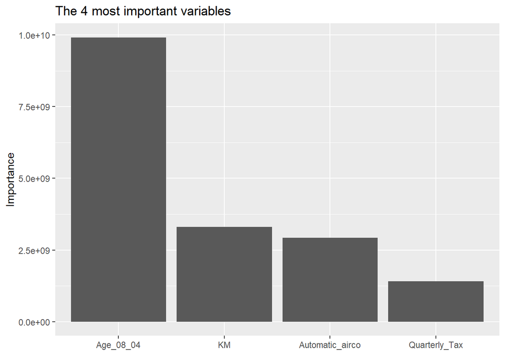

```r
importance <- importance[1:4,] # take the 4 most important ones

ggplot(importance, aes(x = reorder(Variables, desc(Importance)), y = Importance)) + # use ggplot to plot the first 4 most important variables and reorder them
  geom_bar(stat = "identity") + # shall be a bar plot with stat = identity
  labs(title = "The 4 most important variables", x = element_blank()) # set title and blank x-axis
```

Another approach that does not directly address the importance of the used variables in the previous model but asks for the 4 best features to predict a car’s price with a 4 feature model is presented in the following. From this viewpoint, this combination can also be referred to as the 4 most important variables to predict a car’s price.  
First, all possible combinations of 4 features are taken and for each of them a new model is created. Then the RMSE is calculated for each model and compared to the best RMSE that has already been achieved by previous models. The “best” combination of 4 features and its RMSE for the training set will be kept.

```r
combinations <- combinations(15, 4, repeats.allowed=FALSE) # produce all combinations without repetitions for 18 numbers on 4 spots
training2to16 <- as.data.frame(training[,2:16]) # exclude price
min = 100000 # set the minimum value to a large number
minSet = "" # set the variable to store the best set
la <- length(combinations)/4 # take the length of computations and divide it by 4 because the rows of each column count into length
for (i in 1:la){ # go through all combinations
  set.seed(1)
  set <- c(combinations[i,1], combinations[i,2], combinations[i,3], combinations[i,4]) # set set to the current combination of features
  subset <- training2to16[, set] # make a subset of these features
  subset <- data.frame(subset, "Price" = training$Price) # add price to this subset
  combRegrTree <- rpart(Price ~ ., data = subset, control = rpart.control(maxdepth = 30, minbucket = 1, cp = 0.001)) # run a regression tree for this subset
  combRegrPred <- predict(combRegrTree, training) # predict based on the created regression tree
  rmse <- RMSE(combRegrPred, training$Price) # calculate the standard error
  if (rmse < min){ # if a new "best" combination was found
    min = rmse # set min to the new minimal RMSE
    minSet = set # save the new "best" set
  }
}

# printing the results
print(paste("Minimal RMSE:", round(min,4)))
```

```
## [1] "Minimal RMSE: 1009.3143"
```

```r
print(paste("Best set:", colnames(training2to16[,minSet][1]), colnames(training2to16[,minSet][2]), colnames(training2to16[,minSet][3]), colnames(training2to16[,minSet][4])))
```

```
## [1] "Best set: Age_08_04 KM HP Airco"
```

### ii)

#### Compare the prediction error of the training and validation sets by examining their RMS error and by plotting two boxplots. How does the performance of the validation set compare to the training set? Why does this occur?

The first step is to predict the prices for both, the training and the validation set, using the regression tree which was derived before.

```r
set.seed(1)
predTraining <- predict(regrTreeTra, training) # store the result of predicting the training set prices in predTraining
set.seed(1)
predValidation <- predict(regrTreeTra, validation) # store the result of predicting the validation set prices in predValidation
```

The predicted prices are to be organised in a common datatable.

```r
diffTraining <- data.table("pricesTraining" = training$Price, "prediction" = predTraining, "diff" = training$Price - predTraining) # new datatable with the true prices, the predictions and their difference for training
diffValidation <- data.table("pricesValidation" = validation$Price, "prediction" = predValidation, "diff" = validation$Price - predValidation) # new datatable with the true prices, the predictions and their difference for validation
```

This leads to the following RMSEs.

```r
RMSE(diffTraining$prediction, diffTraining$pricesTraining) # RMSE for training
```

```
## [1] 974.5834
```

```r
RMSE(diffValidation$prediction, diffValidation$pricesValidation) # RMSE for training
```

```
## [1] 1264.583
```

The predictive performance for the training set is better than for the validation set, at least referring to RMSE.  
This can also be seen in the boxplots below.

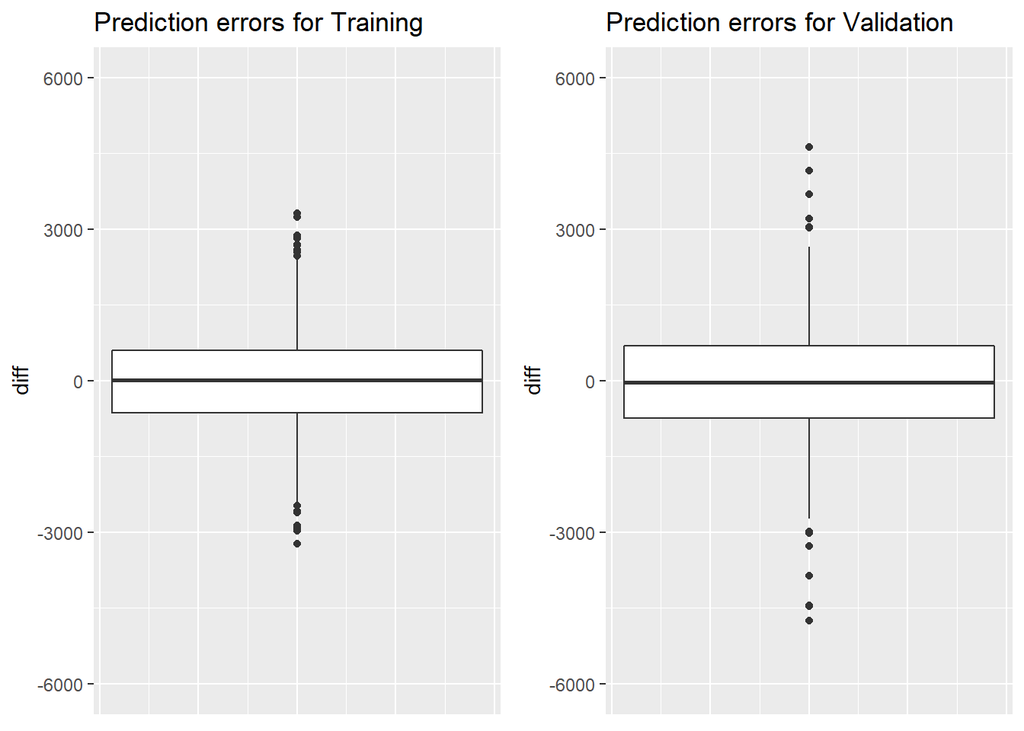

```r
trainingPlot <- ggplot(diffTraining, aes(y=diff)) + # new ggplot with diffTraining as data, use as y-axis the difference diff
  geom_boxplot() + # create a boxplot
   labs(title = "Prediction errors for Training") + # set the title
   theme(axis.title.x = element_blank(), # empty x-axis
         axis.text.x = element_blank(),
         axis.ticks.x = element_blank()) +
   coord_cartesian(ylim = c(-6000, 6000)) # set y-axis limits

validationPlot <- ggplot(diffValidation, aes(y=diff)) + # new ggplot with diffValidation as data, use as y-axis the difference diff
   geom_boxplot() + # create a boxplot
   labs(title = "Prediction errors for Validation") + # set the title
   theme(axis.title.x = element_blank(), # empty x-axis
         axis.text.x = element_blank(),
         axis.ticks.x = element_blank()) +
   coord_cartesian(ylim = c(-6000, 6000)) # set y-axis limits

require(gridExtra) # needed for combining two ggplots
grid.arrange(trainingPlot, validationPlot, ncol=2) # combine both ggplots that were created above
```

There are more and stronger outliers in the validation set than in the training set.  
This can be due to over fitting what comes as a result of a too complex, too detailed and too deep tree.

### iii)

#### How might we achieve better validation predictive performance at the expense of training performance?

One might create a less complex and smaller tree that will perform worse on the training data but the loss of performance is no real performance but just over fitting (at least when cutting the tree/creating a smaller tree appropriately). This loss on the training data prediction might lead to a better performance on new data like the validation data, which shows the “real” quality of the model.

### iv)

#### Create a less deep tree by leaving the arguments cp, minbucket, and maxdepth at their default values. Compare to the deeper tree, what is the predictive performance on the validation set?

First, the new tree will be created.

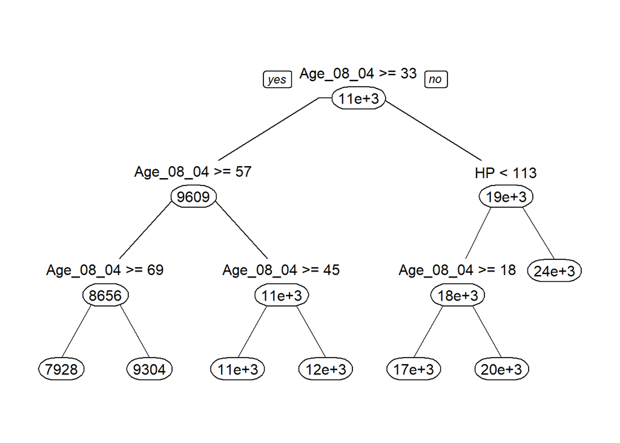

```r
set.seed(1) # reproducability
regrTreeSmall <- rpart(Price ~ ., data = training) # run a regression tree with default values for cp, minbucket and maxdepth
prp(regrTreeSmall, type = 1, split.font = 1, varlen = -10) # plot the regression tree
```

```r
length(regrTreeSmall$frame$var[regrTreeSmall$frame$var == "<leaf>"]) # number of final nodes
```

```
## [1] 7
```

```r
# create a datatable to gather the data
set.seed(1) # reproducability
predVSmall <- predict(regrTreeSmall, validation) # predict the data from the validation set with the smaller tree
performanceSmall <- data.table("TruePrices" = validation$Price, "PredictionSmall" = predVSmall, "PredictionDeep" = predValidation, "DiffSmall" = validation$Price - predVSmall, "DiffDeep" = validation$Price - predValidation) # create a new datatable with the true prices, the predictions and the error terms

# calculate RMSEs for both trees for the validation set
RMSE(performanceSmall$PredictionDeep, performanceSmall$TruePrices)
```

```
## [1] 1264.583
```

```r
RMSE(performanceSmall$PredictionSmall, performanceSmall$TruePrices)
```

```
## [1] 1449.754
```

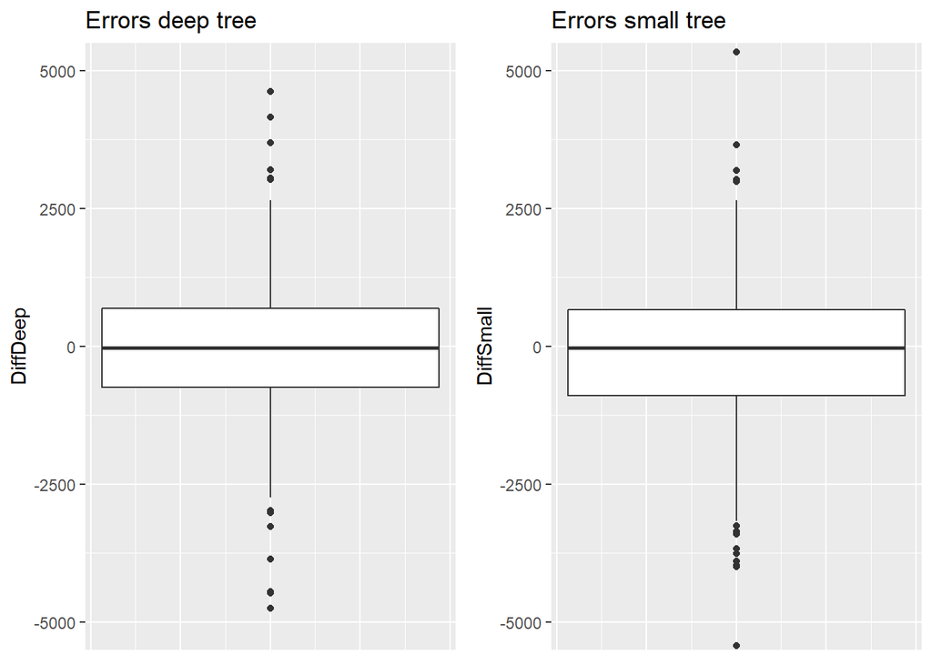

```r
deepPlot <- ggplot(performanceSmall, aes(y = DiffDeep)) +
  geom_boxplot() + # new ggplot with performanceSmall as data and DiffDeep on the y-axis
  coord_cartesian(ylim = c(-5000, 5000)) + # set the limits for the y-axis
  theme(axis.title.x = element_blank(), # empty x-axis
         axis.text.x = element_blank(),
         axis.ticks.x = element_blank()) +
  labs(title = "Errors deep tree") # set the title

# same approach as above but for the smaller tree
smallPlot <- ggplot(performanceSmall, aes(y = DiffSmall)) +
  geom_boxplot() +
  coord_cartesian(ylim = c(-5000, 5000)) +
  theme(axis.title.x = element_blank(),
         axis.text.x = element_blank(),
         axis.ticks.x = element_blank()) +
  labs(title = "Errors small tree")

require(gridExtra) # needed for combining two ggplots
grid.arrange(deepPlot, smallPlot, ncol=2) # combine both ggplots that were created above
```

One can observe a few more outliers in the boxplot of the small tree but the median 50% look only slightly bigger. Also, the median is pretty close to 0 for both trees.  
The predictive performance on the validation set has not been improved through using a smaller tree, but it has slightly diminished.

## b)

### Preparation

#### Let us see the effect of turning tne price variable into a categorical variable. First, create a new variable that categorizes price into 20 bins. Now repartition the data keeping Binned_Price instead of Price. Run a regression tree with the same set of input variables as in the RT, and with Binned_Price as the output variable. As in the less deep regression tree, leave the arguments cp, minbucket, and maxdepth at their defaults.

```r
corolla$BinnedPrice <- cut2(corolla$Price, g = 20) # partition Price into 20 groups
```

The data must now be re-sampled.

```r
# repartitioning
set.seed(1) # reproducability
trainingIndex = sample(seq_len(nrow(corolla)), size = 0.6*nrow(corolla)) # 60% of the indices of corolla shall be assigned to trainingIndex
training = corolla[trainingIndex,] # assign the to trainingIndex corresponding values to training
validation = corolla[-trainingIndex,] # the values that have not been assigned to training are added to validation
```

Again, the desired variables have to be selected.

```r
# variable selection

variables <- c("BinnedPrice", "Age_08_04", "KM", "Fuel_Type", "HP", "Automatic", "Doors", "Quarterly_Tax", "Mfr_Guarantee", "Guarantee_Period", "Airco", "Automatic_airco", "CD_Player", "Powered_Windows", "Sport_Model", "Tow_Bar") # set the variables that shall be used according to the task
training = training[, ..variables] # reduce the training set to the previously assigned variables
```

### Classification tree

Here, the new classification tree will be created, leaving the values for rpart.control on default.

```r
set.seed(1) # reproducability
classTreeb <- rpart(BinnedPrice ~ ., data = training) # create a classification tree like the regression tree above
```

### i)

#### Compare the tree generated by the CT with the one generated by the RT. Are they different? (Look at the structure, the top predictors, size of tree, etc.) Why?

At first, both trees will be plotted, using prp.

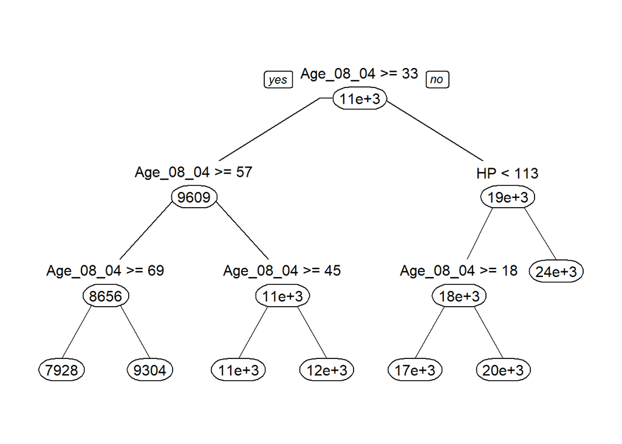

```r
prp(regrTreeSmall, type = 1, split.font = 1, varlen = -10) # plot the regression tree
```

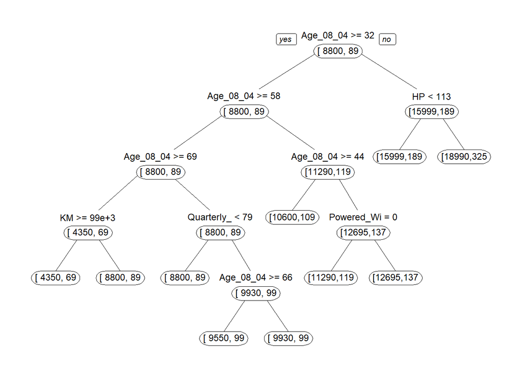

```r
prp(classTreeb, type = 1, split.font = 1, varlen = -10) # plot the classification tree
```

In the following, the characteristics of the trees will be examined and compared in detail, using the printcp() function.

```r
printcp(regrTreeSmall) # show details of the regression tree
```

```
##
## Regression tree:
## rpart(formula = Price ~ ., data = training)
##
## Variables actually used in tree construction:
## [1] Age_08_04 HP
##
## Root node error: 1.1656e+10/861 = 13537642
##
## n= 861
##
##         CP nsplit rel error  xerror     xstd
## 1 0.665651      0   1.00000 1.00159 0.082928
## 2 0.115033      1   0.33435 0.35044 0.029499
## 3 0.031177      2   0.21932 0.23186 0.026809
## 4 0.020108      3   0.18814 0.22028 0.023567
## 5 0.016860      4   0.16803 0.19641 0.020892
## 6 0.014068      5   0.15117 0.18595 0.020340
## 7 0.010000      6   0.13710 0.17212 0.019626
```

```r
printcp(classTreeb) # show details of the classification tree
```

```
##
## Classification tree:
## rpart(formula = BinnedPrice ~ ., data = training)
##
## Variables actually used in tree construction:
## [1] Age_08_04       HP              KM              Powered_Windows
## [5] Quarterly_Tax
##
## Root node error: 785/861 = 0.91173
##
## n= 861
##
##         CP nsplit rel error  xerror     xstd
## 1 0.070064      0   1.00000 1.00000 0.010604
## 2 0.021656      2   0.85987 0.86115 0.015353
## 3 0.015287      3   0.83822 0.86624 0.015231
## 4 0.014013      4   0.82293 0.85605 0.015472
## 5 0.013376      5   0.80892 0.84459 0.015730
## 6 0.012739      7   0.78217 0.84459 0.015730
## 7 0.010191      8   0.76943 0.82675 0.016103
## 8 0.010000      9   0.75924 0.81274 0.016375
```

### ii)

#### Predict the price, using the RT and the CT, of a used Toyota Corolla with the specifications listed in Table 9.6.

At first, the new entity with the given characteristics has to be created. Then the prediction will be made.

```r
set.seed(1)
newEntity <- data.table("Age_08_04" = 77, "KM" = 117000, "Fuel_Type" = "Petrol", "HP" = 110, "Automatic" = 0, "Doors" = 5, "Quarterly_Tax" = 100, "Mfr_Guarantee" = 0, "Guarantee_Period" = 3, "Airco" = 1, "Automatic_airco" = 0, "CD_Player" = 0, "Powered_Windows" = 0, "Sport_Model" = 0, "Tow_Bar" = 1) # set the new entity's values
#predict(regrTreeTra, newEntity)
predictionRegrTree <- predict(regrTreeTra, newEntity) # predict the price for the new entity using the regression tree
predictionRegrTree
```

```
##        1
## 7266.207
```

```r
set.seed(1) # reproducability
predictionClassTree <- predict(classTreeb, newEntity, type = 'class') # predict the price for the new entity using the classification tree
predictionClassTree
```

```
##             1
## [ 4350, 6950)
## 19 Levels: [ 4350, 6950) [ 6950, 7460) [ 7460, 7795) ... [18990,32500]
```

### iii)

#### Compare the predictions in terms of the predictors that were used, the magnitude of the difference between the two predictors, and the advantages and disadvantages of the two methods.

```r
predictionRegrTree
```

```
##        1
## 7266.207
```

```r
predictionClassTree
```

```
##             1
## [ 4350, 6950)
## 19 Levels: [ 4350, 6950) [ 6950, 7460) [ 7460, 7795) ... [18990,32500]
```

Finally, the variable importances according to the the inherit information of the trees are compared between the classification tree and the regression tree.

At first, the classification tree will examined.

```r
importanceClassTree <- data.frame(classTreeb$variable.importance) # extract the variable importance directly from the classification tree
importanceClassTree <- rownames_to_column(importanceClassTree, var = "Variables") # set the column name of the variables to "Variables"
importanceClassTree <- data.table("Variables" = importanceClassTree$Variables, "Importance" = importanceClassTree$classTreeb.variable.importance) # make it a datatable
importanceClassTree <- importanceClassTree[1:4,] # select the 4 most important ones
```

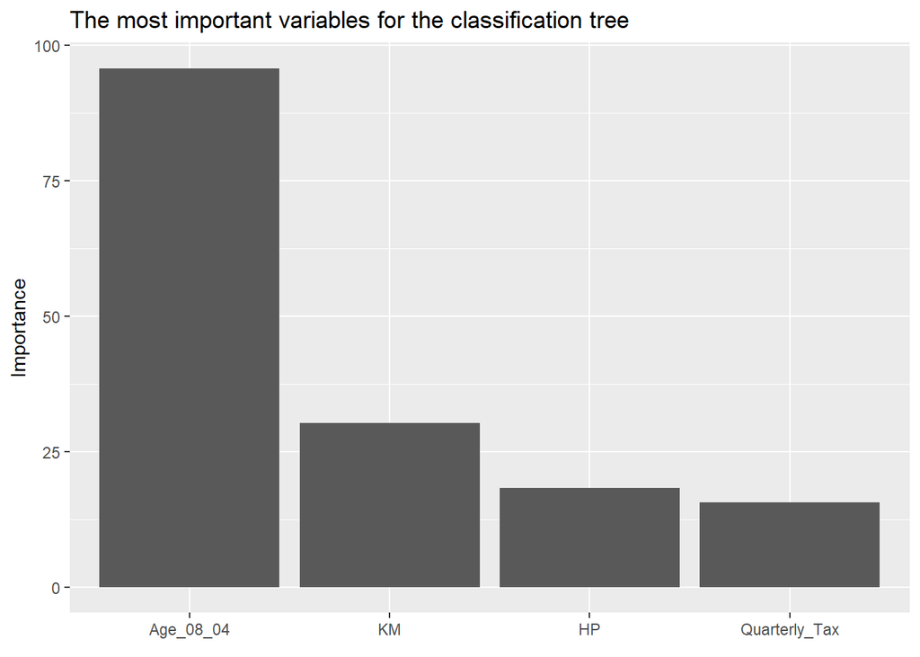

```r
ggplot(importanceClassTree, aes(x = reorder(Variables, desc(Importance)), y = Importance)) + # create a new ggplot with importance as data and reorder the data by descending importance
  geom_bar(stat = "identity") + # barplot with stat = "identity
  labs(title = "The most important variables for the classification tree", x = element_blank()) # set title and empty x-axis
```

The same approach will be followed for the regression tree.

```r
importanceRegrTree <- data.frame(regrTreeSmall$variable.importance) # extract the variable importance directly from the classification tree
importanceRegrTree <- rownames_to_column(importanceRegrTree, var = "Variables")
importanceRegrTree <- data.table("Variables" = importanceRegrTree$Variables, "Importance" = importanceRegrTree$regrTreeSmall.variable.importance)
importanceRegrTree <- importanceRegrTree[1:4,]
```

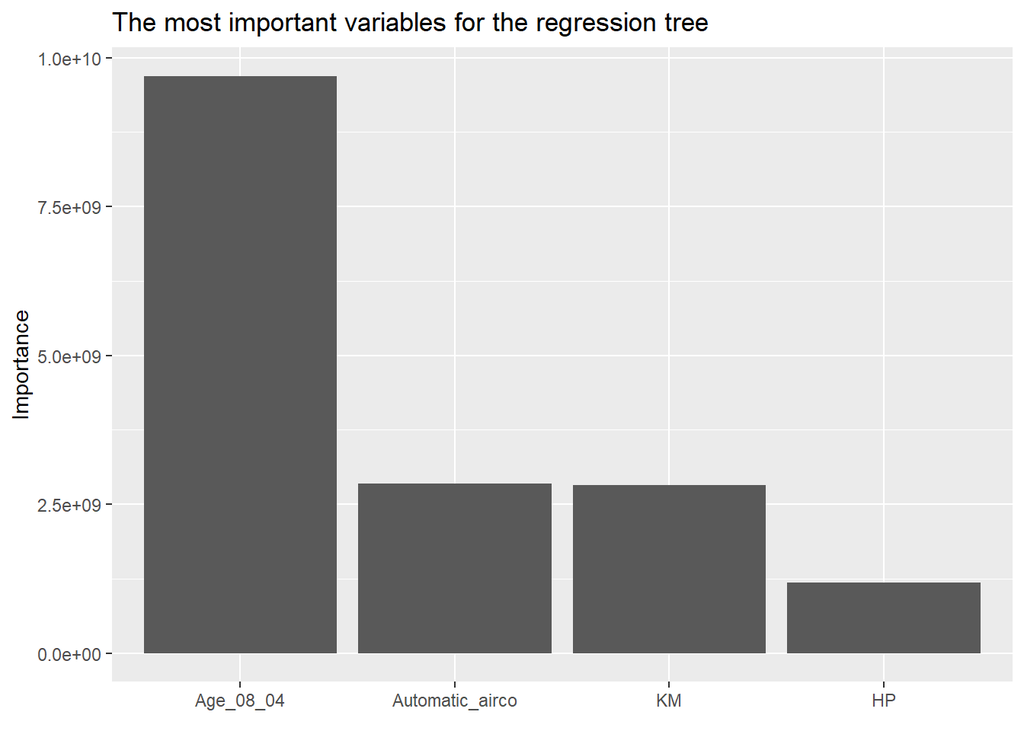

```r
ggplot(importanceRegrTree, aes(x = reorder(Variables, desc(Importance)), y = Importance)) + # create a new ggplot with importance as data and reorder the data by descending importance
  geom_bar(stat = "identity") + # barplot with stat = "identity
  labs(title = "The most important variables for the regression tree", x = element_blank()) # set title and empty x-axis
```

Both trees rank Age as the most important one and include mileage and HP on the ranks 2 to 4. The regression tree sees automatic air-condition on the second rank while the classification tree includes quarterly tax on rank 4.

Comparing the methods Classification trees can be used when one has categorical values for the dependent variable while regression trees can only be used for numerical values in the dependent variable. As could be seen in this task, numerical values can be turned into categorical ones, what is not possible the way around. So, classification trees can be used in more situations.  
Depending on the aim of the tree, it can be useful to obtain a single value, when one should use a regression tree or an interval, when one should use a classification tree.

## References

### Packages

Dowle M, Srinivasan A (2021). *data.table: Extension of `data.frame`*. R package version 1.14.2, https://CRAN.R-project.org/package=data.table.

Kuhn M (2022). *caret: Classification and Regression Training*. R package version 6.0-93, https://CRAN.R-project.org/package=caret.

Harrell Jr F (2022). *Hmisc: Harrell Miscellaneous*. R package version 4.7-1, https://CRAN.R-project.org/package=Hmisc.

Therneau T, Atkinson B (2022). *rpart: Recursive Partitioning and Regression Trees*. R package version 4.1.16, https://CRAN.R-project.org/package=rpart.

Milborrow S (2022). *rpart.plot: Plot ‘rpart’ Models: An Enhanced Version of ‘plot.rpart’*. R package version 3.1.1, https://CRAN.R-project.org/package=rpart.plot.

Wickham H, Averick M, Bryan J, Chang W, McGowan LD, François R, Grolemund G, Hayes A, Henry L, Hester J, Kuhn M, Pedersen TL, Miller E, Bache SM, Müller K, Ooms J, Robinson D, Seidel DP, Spinu V, Takahashi K, Vaughan D, Wilke C, Woo K, Yutani H (2019). “Welcome to the tidyverse.” *Journal of Open Source Software*, *4*(43), 1686. doi:10.21105/joss.01686 https://doi.org/10.21105/joss.01686.

Bolker B, Warnes G, Lumley T (2022). *gtools: Various R Programming Tools*. R package version 3.9.3, https://CRAN.R-project.org/package=gtools.